# Urban Heat Island, Tree Cover, and the 2017 American Community Survey

2019-08-01T00:00:00Z

Air temperatures in cities are substantially higher than in adjacent rural areas. In the United States, the average difference can be as much as 16°F for severely affected cities (Imoff et al. 2010). This phenomenon, known as urban heat island (UHI), results from differences in surface heat reflection and absorption. High levels of dark, impervious surfaces; lack of vegetation; and urban geometries increase absorption and decrease evapotranspiration. This leads to increases in temperature and thermal discomfort. Increased thermal discomfort can cause psychological stress, decrease productivity, and lead to death in vulnerable populations (Poumadere 2003, Kovats 2008, Kjellstrom 2009).

One cost effective way to mitigate UHI is through a mature tree canopy. However, trees are not evenly distributed in American cities. The 2017 American Community survey, tree canopy data, and UHI around Austin, TX shows patterns in how trees are distributed by income and race.

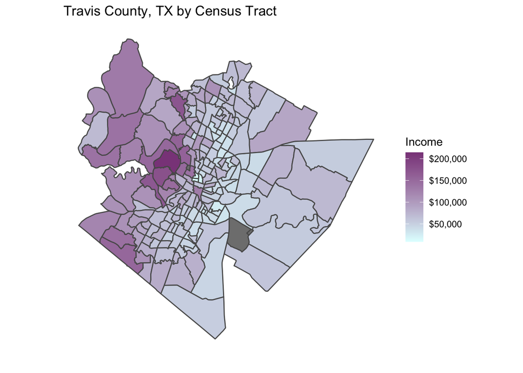

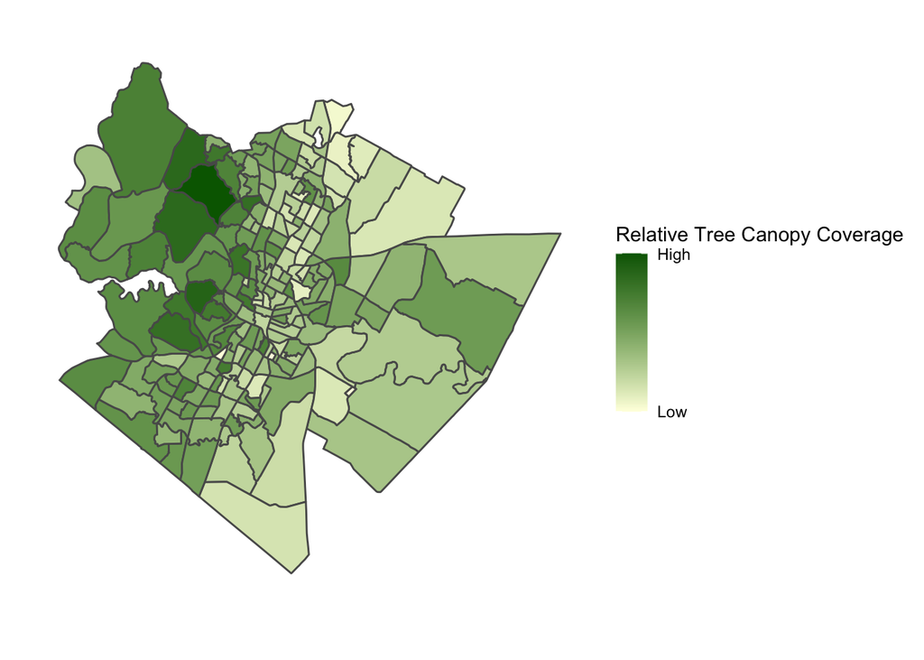

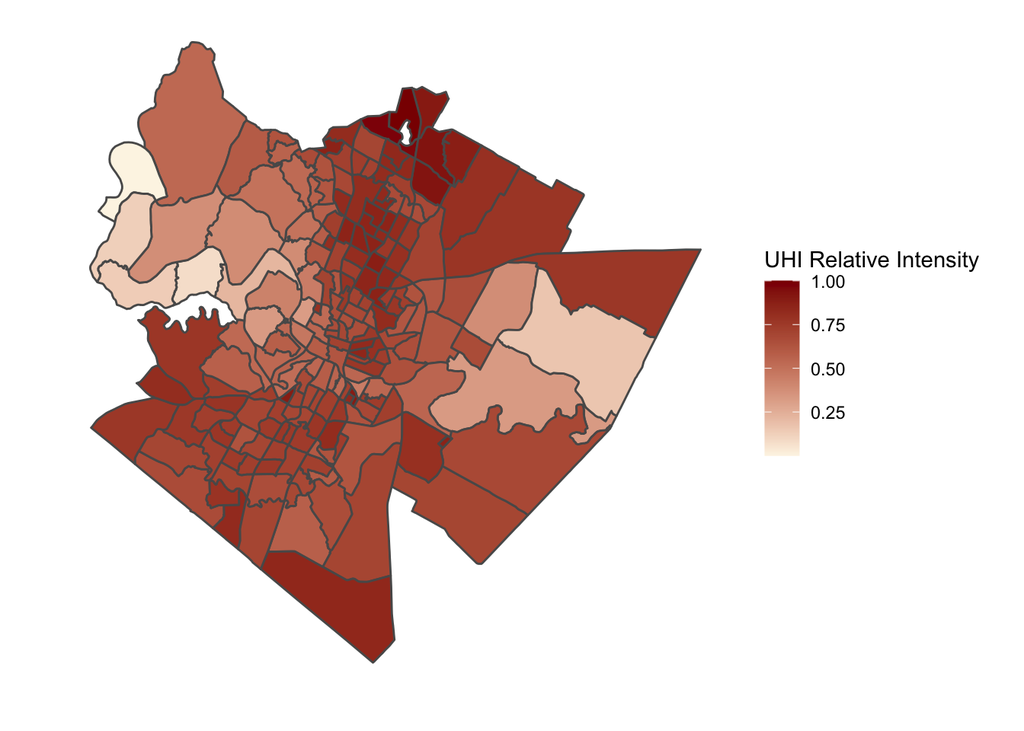

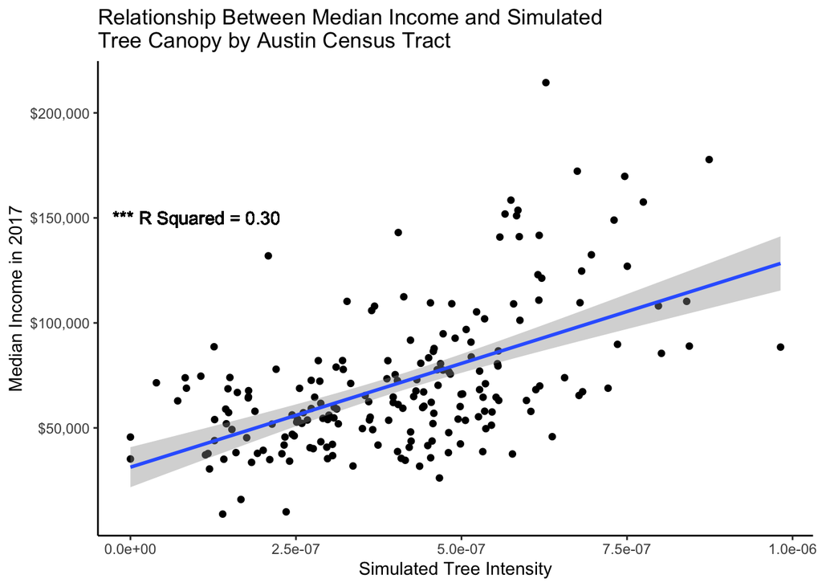

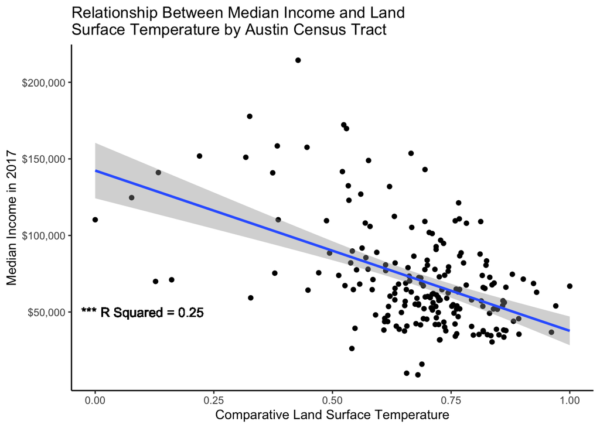

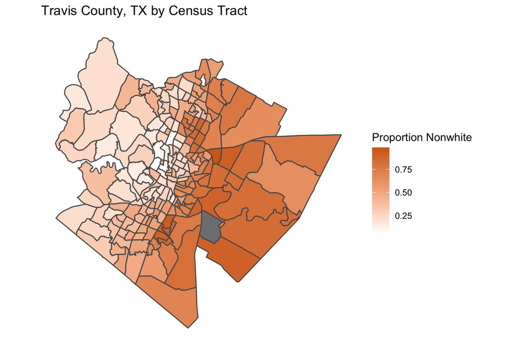

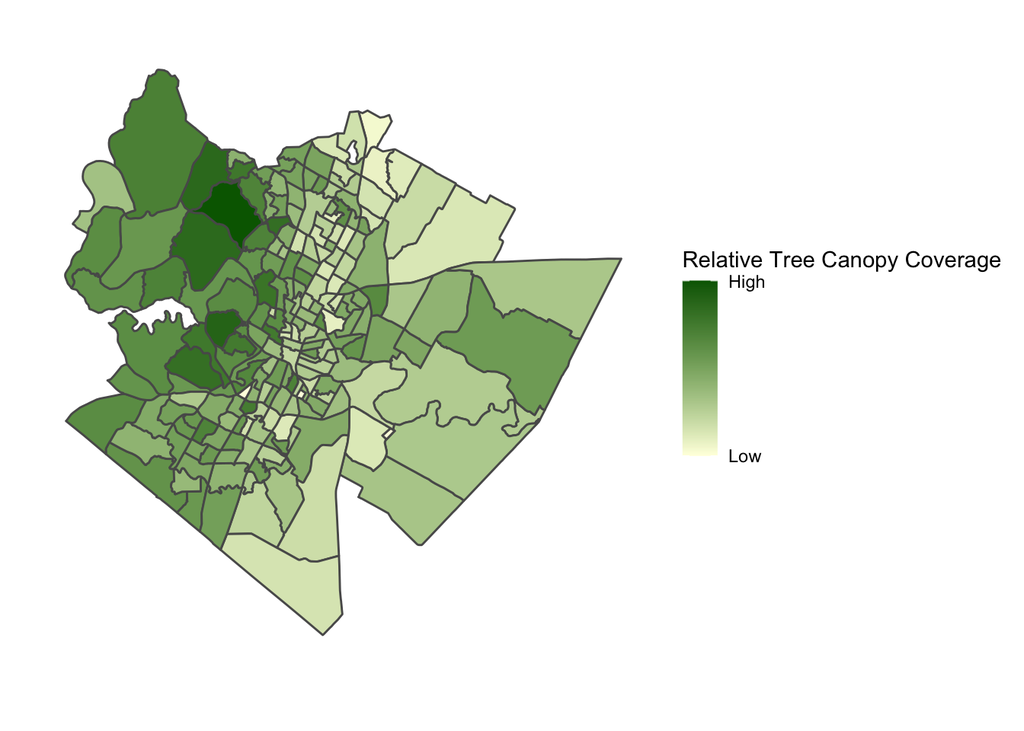

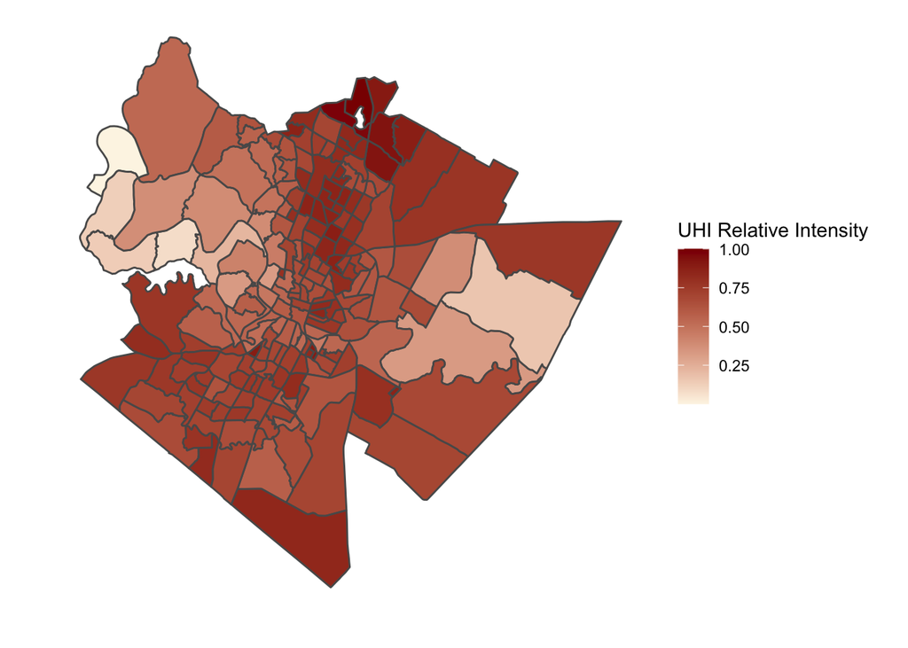

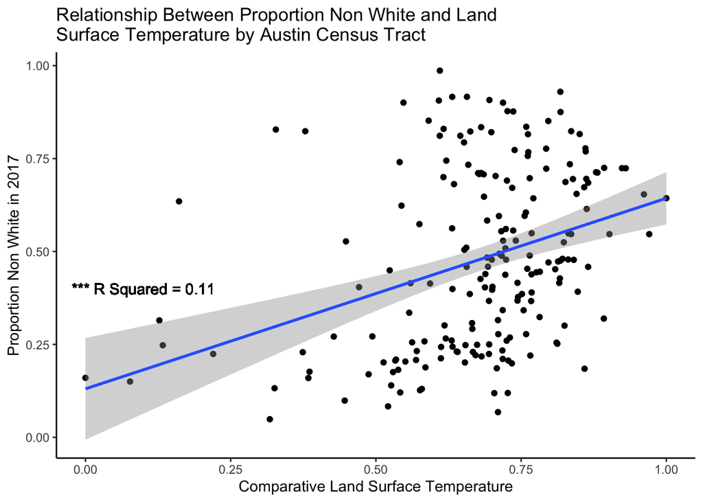

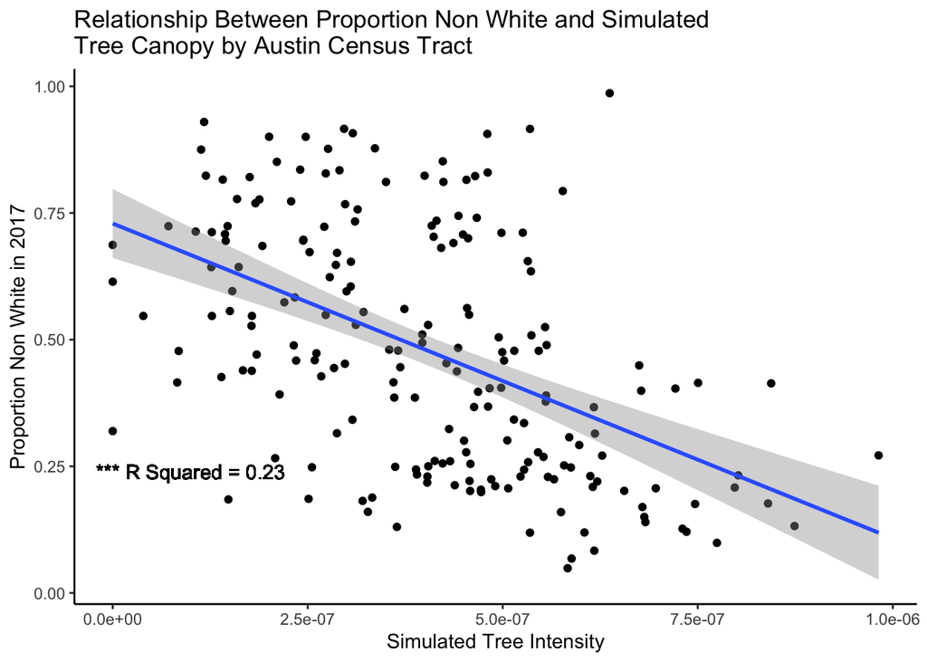

## References

Imhoff ML, Zhang P, Wolfe RE, Bounoua L. Remote sensing of the urban heat island effect across biomes in the continental USA. Remote Sens Environ. 2010;114(3):504-513. doi:10.1016/j.rse.2009.10.008

Karimipour N. Implications of Urban Design Strategies for Urban Heat Islands: An Investigation of the UHI Effect in Downtown Austin, Texas. 2017.

Kjellstrom T, Holmer I, Lemke B. Workplace heat stress, health and productivity – an increasing challenge for low and middle-income countries during climate change. Glob Health Action. 2009;2(1):2047. doi:10.3402/gha.v2i0.2047

Kovats RS, Hajat S. Heat Stress and Public Health: A Critical Review. Annu Rev Public Health. 2008;29(1):41-55. doi:10.1146/annurev.publhealth.29.020907.090843

Poumadere M, Mays C, Le Mer S, Blong R. The 2003 Heat Wave in France: Dangerous Climate Change Here and Now. Risk Anal Off Publ Soc Risk Anal. 2006;25:1483-1494. doi:10.1111/j.1539-6924.2005.00694.x

Richardson S. A GEOSPATIAL ANALYSIS OF THE URBAN HEAT ISLAND EFFECT IN AUSTIN, TX. May 2015.

Urban heat island data is based off of land surface temperature taken in 2014 (https://data.austintexas.gov/Locations-and-Maps/Tree-Planting-Prioritization-2014/psx7-v95h)

Tree canopy cover is based off a 2014 City of Austin raster dataset. Contact for further details.